# QK Box 8.2

Loyn (1987) selected 56 forest patches in southeastern Victoria, Australia, and related the abundance of forest birds in each patch to six predictor variables: patch area (ha), distance to nearest patch (km), distance to nearest larger patch (km), grazing stock (1 to 5 indicating light to heavy), altitude (m) and years since isolation (years). The aim was to develop a predictive model relating bird abundance to these predictors and to assess which predictors were most important for bird abundance.

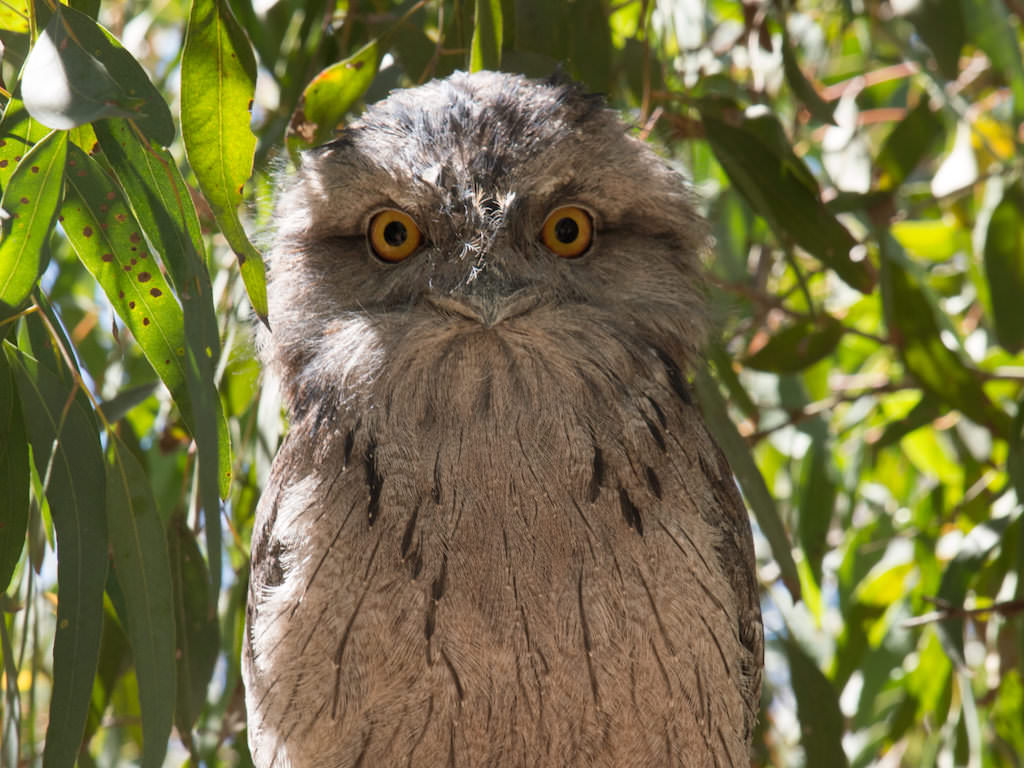

Tawny Frogmouth, Podargus strigoides. Mick Keough, [CC BY 4.0](https://creativecommons.org/licenses/by/4.0/)

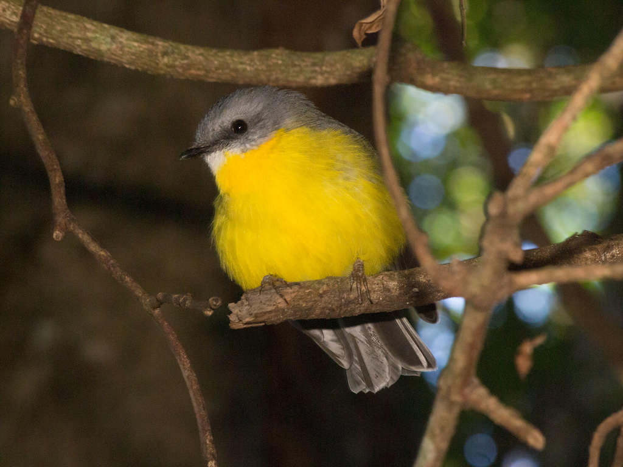

Eastern Yellow Robin, *Eopsaltria australis*. Emmet Keough, [CC BY 4.0](https://creativecommons.org/licenses/by/4.0/)

### Preliminaries

First, load the required packages (car, lm.beta, hier.part)

Import loyn data file (loyn.csv)

```r
loyn <- read.csv("../data/loyn.csv")
head(loyn,10)
```

|  | abund | area | yearisol | dist | distl | graze | alt |
| --- | --- | --- | --- | --- | --- | --- | --- |
| 1 | 5.3 | 0.1 | 1968 | 39 | 39 | 2 | 160 |
| 2 | 2.0 | 0.5 | 1920 | 234 | 234 | 5 | 60 |
| 3 | 1.5 | 0.5 | 1900 | 104 | 311 | 5 | 140 |
| 4 | 17.1 | 1.0 | 1966 | 66 | 66 | 3 | 160 |
| 5 | 13.8 | 1.0 | 1918 | 246 | 246 | 5 | 140 |
| 6 | 14.1 | 1.0 | 1965 | 234 | 285 | 3 | 130 |
| 7 | 3.8 | 1.0 | 1955 | 467 | 467 | 5 | 90 |
| 8 | 2.2 | 1.0 | 1920 | 284 | 1829 | 5 | 60 |
| 9 | 3.3 | 1.0 | 1965 | 156 | 156 | 4 | 130 |
| 10 | 3.0 | 1.0 | 1900 | 311 | 571 | 5 | 130 |

```r
NA
```

### Check distributions of predictors and look for correlations

We will use the scatterplotMatrix function from the car package

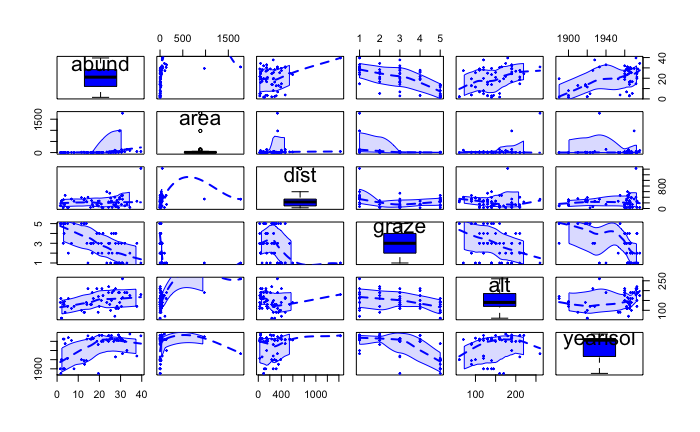

```r
scatterplotMatrix(~abund+area+dist+graze+alt+yearisol, data=loyn, cex=0.33, regLine=FALSE, diagonal=list(method='boxplot'))
```

abund looks symmetrical but two unusual observations for area resulting in non-linear relationships with abund and one outlier for distance to nearest patch

#### Try log(10) transformation of area and dist

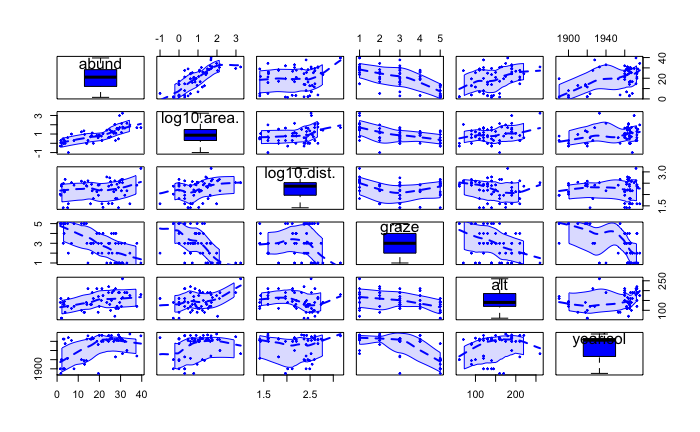

```r
scatterplotMatrix(~abund+log10(area)+log10(dist)+graze+alt+yearisol, data=loyn, cex=0.33, regLine=FALSE, diagonal=list(method='boxplot'))
```

Plots look much better. Now transform the variables in loyn

```r
loyn$logarea <- log10(loyn$area)
loyn$logdist <- log10(loyn$dist)
```

### Now check for collinearity among predictors (using larea and ldist)

Use correlations and VIF

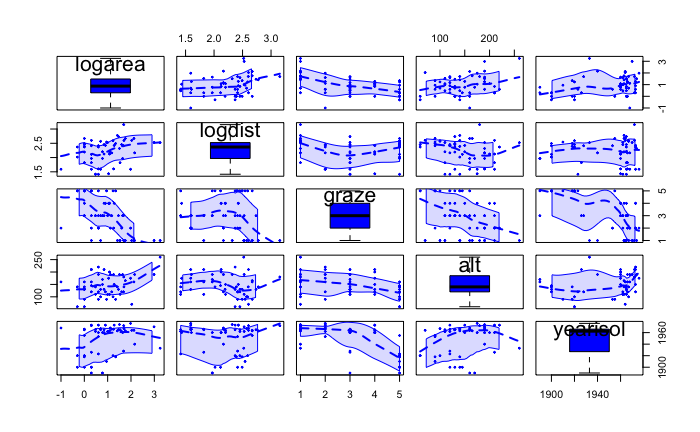

```r
scatterplotMatrix(~logarea+logdist+graze+alt+yearisol, data=loyn, cex=0.33, regLine=FALSE, diagonal=list(method='boxplot'))
```

```r
cor(loyn[,c('logarea','logdist','graze','alt','yearisol')])
```

```
         logarea logdist  graze    alt yearisol
logarea    1.000  0.3022 -0.559  0.275   0.2784
logdist    0.302  1.0000 -0.143 -0.219  -0.0196
graze     -0.559 -0.1426  1.000 -0.407  -0.6356
alt        0.275 -0.2190 -0.407  1.000   0.2327
yearisol   0.278 -0.0196 -0.636  0.233   1.0000
```

```r
vif(lm(abund~ logarea+logdist+graze+alt+yearisol, data=loyn))
```

```
 logarea  logdist    graze      alt yearisol
    1.62     1.27     2.52     1.36     1.74
```

Collinearity OK so now fit linear model relating response to predictor

```r
loyn.lm <- lm(abund~ logarea+logdist+graze+alt+yearisol, data=loyn)
```

### Examine regression diagnostics (residual plot and Cooks D)

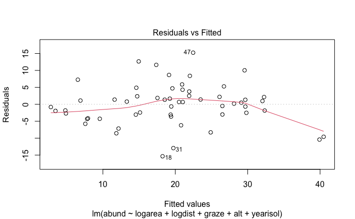

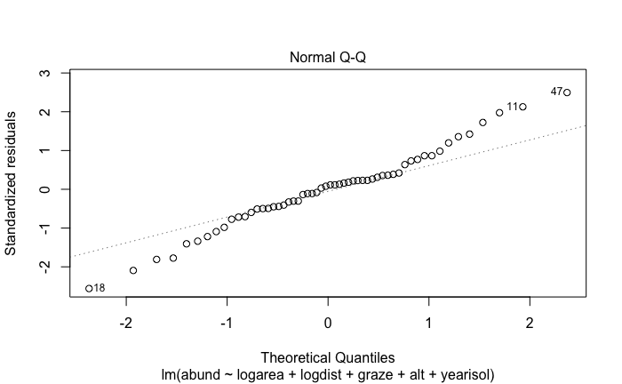

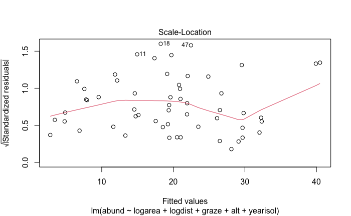

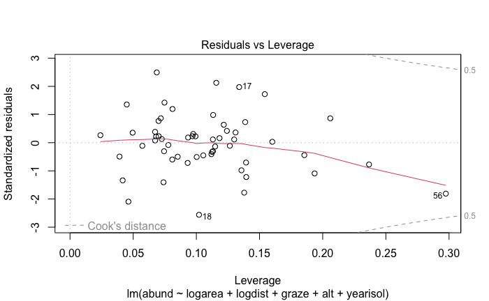

```r
plot(loyn.lm)
```

```r
augment(loyn.lm)
```

| abund | logarea | logdist | graze | alt | yearisol | .fitted | .resid | .hat | .sigma | .cooksd | .std.resid |
| --- | --- | --- | --- | --- | --- | --- | --- | --- | --- | --- | --- |
| 5.3 | -1.000 | 1.59 | 2 | 160 | 1968 | 9.57 | -4.273 | 0.2367 | 6.35 | 3.09e-02 | -0.7732 |
| 2.0 | -0.301 | 2.37 | 5 | 60 | 1920 | 2.81 | -0.810 | 0.1149 | 6.39 | 4.01e-04 | -0.1361 |
| 1.5 | -0.301 | 2.02 | 5 | 140 | 1900 | 3.45 | -1.953 | 0.1125 | 6.38 | 2.27e-03 | -0.3278 |
| 17.1 | 0.000 | 1.82 | 3 | 160 | 1966 | 14.74 | 2.358 | 0.0673 | 6.38 | 1.79e-03 | 0.3861 |
| 13.8 | 0.000 | 2.39 | 5 | 140 | 1918 | 6.54 | 7.259 | 0.0811 | 6.30 | 2.11e-02 | 1.1972 |
| 14.1 | 0.000 | 2.37 | 3 | 130 | 1965 | 13.31 | 0.795 | 0.0726 | 6.39 | 2.22e-04 | 0.1305 |
| 3.8 | 0.000 | 2.67 | 5 | 90 | 1955 | 7.94 | -4.139 | 0.1393 | 6.36 | 1.34e-02 | -0.7053 |
| 2.2 | 0.000 | 2.45 | 5 | 60 | 1920 | 4.90 | -2.697 | 0.1055 | 6.38 | 3.99e-03 | -0.4508 |
| 3.3 | 0.000 | 2.19 | 4 | 130 | 1965 | 11.86 | -8.559 | 0.0740 | 6.26 | 2.63e-02 | -1.4061 |
| 3.0 | 0.000 | 2.49 | 5 | 130 | 1900 | 4.82 | -1.815 | 0.1131 | 6.38 | 1.97e-03 | -0.3047 |

[output cut: 46 more lines]

### Display results of model fitting

Get parameter estimates, their confidence intervals, and tests

```r
tidy(loyn.lm, conf.int=TRUE)
```

| term | estimate | std.error | statistic | p.value | conf.low | conf.high |
| --- | --- | --- | --- | --- | --- | --- |
| (Intercept) | -131.8474 | 88.6398 | -1.487 | 1.43e-01 | -309.8856 | 46.1909 |
| logarea | 7.2953 | 1.3360 | 5.460 | 1.49e-06 | 4.6118 | 9.9788 |
| logdist | -1.3032 | 2.3189 | -0.562 | 5.77e-01 | -5.9608 | 3.3543 |
| graze | -1.6757 | 0.9211 | -1.819 | 7.49e-02 | -3.5258 | 0.1743 |
| alt | 0.0214 | 0.0229 | 0.937 | 3.53e-01 | -0.0245 | 0.0674 |
| yearisol | 0.0766 | 0.0439 | 1.744 | 8.74e-02 | -0.0116 | 0.1648 |

### Get standarised regression coefficients

Use lm.beta function from lm.beta package

```r
lm.beta.loyn <- lm.beta(loyn.lm)
summary(loyn.lm)
```

```
Call:
lm(formula = abund ~ logarea + logdist + graze + alt + yearisol,
    data = loyn)

Residuals:
    Min      1Q  Median      3Q     Max
-15.344  -3.055   0.575   2.390  15.235

Coefficients:
             Estimate Std. Error t value Pr(>|t|)
(Intercept) -131.8474    88.6398   -1.49    0.143
logarea        7.2953     1.3360    5.46  1.5e-06 ***
logdist       -1.3032     2.3189   -0.56    0.577
graze         -1.6757     0.9211   -1.82    0.075 .
alt            0.0214     0.0229    0.94    0.353
yearisol       0.0766     0.0439    1.74    0.087 .
---
Signif. codes:  0 ‘***’ 0.001 ‘**’ 0.01 ‘*’ 0.05 ‘.’ 0.1 ‘ ’ 1

Residual standard error: 6.33 on 50 degrees of freedom
Multiple R-squared:  0.684, Adjusted R-squared:  0.653
F-statistic: 21.7 on 5 and 50 DF,  p-value: 1.78e-11
```

```r
tidy(lm.beta.loyn, conf.int=TRUE)
```

| term | estimate | std_estimate | std.error | statistic | p.value | conf.low | conf.high |
| --- | --- | --- | --- | --- | --- | --- | --- |
| (Intercept) | -131.8474 | NA | 88.6398 | -1.487 | 1.43e-01 | NA | NA |
| logarea | 7.2953 | 0.5521 | 1.3360 | 5.460 | 1.49e-06 | -2.1314 | 3.236 |
| logdist | -1.3032 | -0.0502 | 2.3189 | -0.562 | 5.77e-01 | -4.7078 | 4.607 |
| graze | -1.6757 | -0.2296 | 0.9211 | -1.819 | 7.49e-02 | -2.0797 | 1.620 |
| alt | 0.0214 | 0.0870 | 0.0229 | 0.937 | 3.53e-01 | 0.0410 | 0.133 |
| yearisol | 0.0766 | 0.1825 | 0.0439 | 1.744 | 8.74e-02 | 0.0943 | 0.271 |

Show the partial regression (added-variable) plots

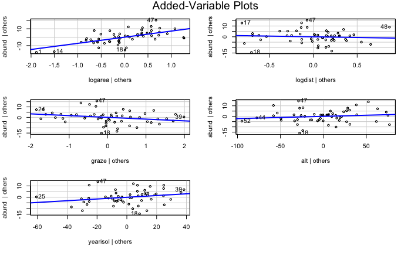

```r
avPlots(loyn.lm, ask=F)
```

### Run hierarchical partitioning (used later)

We need two dataframes that are subsets of loyn containing the response variable and the predictors

```r
loyn_abund<-loyn$abund
loyn_pred<-subset(loyn, select = c("logarea","logdist","alt","yearisol","graze"))
```

```
$gfs
 [1] 0.0000 0.5477 0.0161 0.1489 0.2534 0.4658 0.5580 0.5836 0.6435 0.6527 0.1957 0.2720 0.4667 0.3297 0.4798 0.4739 0.5853 0.6480 0.6610 0.6629 0.6611 0.6732 0.3707 0.4846 0.4758 0.4887 0.6634 0.6651 0.6788 0.6823 0.4961
[32] 0.6843

$IJ
```

|  | I | J | Total |
| --- | --- | --- | --- |
| logarea | 0.3241 | 0.22351 | 0.5477 |
| logdist | 0.0104 | 0.00566 | 0.0161 |
| alt | 0.0548 | 0.09403 | 0.1489 |
| yearisol | 0.1007 | 0.15262 | 0.2534 |
| graze | 0.1942 | 0.27161 | 0.4658 |

|  | ind.exp.var |
| --- | --- |
| logarea | 47.37 |
| logdist | 1.52 |
| alt | 8.01 |
| yearisol | 14.72 |
| graze | 28.38 |

```
$params
$params$full.model
[1] "y ~ logarea + logdist + alt + yearisol + graze"

$params$family
[1] "gaussian"

$params$link
[1] "default"

$params$gof
[1] "Rsqu"
```

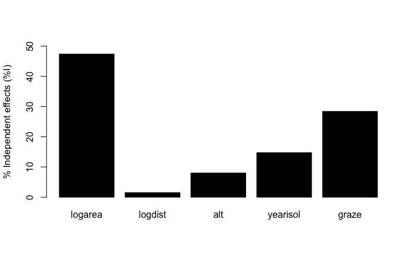

```r
hier.part(loyn_abund, loyn_pred, family="gaussian", gof="Rsqu")
```